https://github.com/mim-uw/eXplainableMachineLearning-2025Z/blob/main/Homeworks/HW1/README.md

# Homework 1

## Task A

### Content

Calculate Shapley values for player A given the following value function

```
v() = 0
v(A) = 20
v(B) = 20
v(C) = 60
v(A,B) = 60
v(A,C) = 70
v(B,C) = 70
v(A,B,C) = 100
```

### Solution

SHAP formula for fair reward sharing is $$ \phi_j = \frac{1}{|P|!} \sum_{\pi \in \Pi} V(S_{j}^{\pi} \cup j) - V(S_{j}^{\pi}) $$ or equivalently $$ \phi_j = \sum_{S \subset P \setminus \{j\}} \frac{|S|! (|P| - |S| - 1)!}{|P|!} V(S \cup j) - V(S) $$ Of course we want to find $\phi_A$ in our case. Less calculation is required in second approach, so let's use it.

$$ \phi_A = \frac{1}{3!} \sum_{S \subset P \setminus \{j\}} |S|! (|P| - |S| - 1)! (V(S \cup j) - V(S)) = $$ $$ |\textit{our next subsets $S$ are:} \emptyset, \{B\}, \{C\}, \{B,C\}| = $$ $$ \frac{1}{6} (2 (20-0) + 1(60-20) + 1(70-60) + 2(100-70)) = \frac{40+40+10+60}{6} = \frac{150}{6} = 25 $$

## Task B

For the selected models, prepare a knitr/jupyter notebook based on the following points. Submit your results on GitHub to the directory `Homeworks/HW1`.

1. Download a dataset from this repository: https://github.com/adrianstando/imbalanced-benchmarking-set (the fewer variables, the easier it is to do your homework)
2. Train a predictive model on the selected dataset; it can be a random forest, NN, GBM, CatBoost, or any other model.
3. Select two observations from the dataset and calculate the model's prediction.
4. Next, for the same observations, calculate the decomposition of predictions, so-called variable attributions, using Shapley values. Implement the Shapley values algorithm on your own. (It is not necessary to calculate the exact Shapley values (those would be time-consuming). You can approximate them by several random permutations of the variables.)
5. Compare results with the one calculated with `shap` package (or any other package that implements this method)
6. Comment on the results obtained in points (3)-(5)

## Part 1

I selected the CatBoostClassifier model because it achieved satisfactory performance and the dataset is imbalanced. I computed Shapley values for the model; however, the results differ significantly from those obtained using the SHAP package. The magnitude of these differences suggests that they are not merely due to approximation error.

Important design choice concerns the definition of the model output used in the Shapley value computation. In my case, the model output is the predicted probability of the positive class. An alternative would be to use the predicted class label (i.e., the class with maximum probability). However, Shapley values are theoretically defined for real-valued model outputs, which makes probabilities a more appropriate choice than hard class labels.

## Appendix

```python
import numpy as np
import pandas as pd

import torch
import torch.nn as nn
import torch.optim as optim
from sklearn.model_selection import train_test_split
from sklearn.preprocessing import StandardScaler
from sklearn.metrics import accuracy_score

from sklearn.ensemble import RandomForestClassifier
from sklearn.model_selection import train_test_split
from sklearn.metrics import accuracy_score, f1_score, roc_auc_score, classification_report

!pip install catboost --quiet

from catboost import CatBoostClassifier
from sklearn.model_selection import train_test_split
from sklearn.metrics import accuracy_score, f1_score, roc_auc_score, classification_report, precision_score, recall_score
```

```python
# Basic data preparation #
# I chose phoneme.csv cause it is one of smaller, only 5 useful columns + labels.
raw_data = pd.read_csv('phoneme.csv')
print("Head:\n", raw_data.head())
print("Are there any NaN values:", raw_data.isna().any().any())
print("Names of columns:", raw_data.columns)
data = raw_data.to_numpy()
print("Data as numpy:\n", data[:5,:])
print("Is first column of indexes:", (data[:,0] == np.arange(data.shape[0])).all())
# We can see that unnamed column is useless so we delete it.
data = data[:,1:]
print("Data without first column, 10 rows:\n", data[:5,:])
y = data[:,-1]
print("Categories in labels:", np.unique(y))
print("Nr of 1 category:", (y == 1).sum())
print("Nr of 2 category:", (y == 2).sum())
# As we can see there are only 2 categories.
X = data[:,:-1]
print("First 5 observations:\n", X[:5, :])
print("First 5 labels:\n", y[:5])
print("Observation dim:", X.shape)
print("Labels dim:", y.shape)
print("Observations dtype:", X.dtype)
print("Labels dtype:", y.dtype)
```

```
Head:
    Unnamed: 0        V1        V2        V3        V4        V5  TARGET
0           0  0.489927 -0.451528 -1.047990 -0.598693 -0.020418       1
1           1 -0.641265  0.109245  0.292130 -0.916804  0.240223       1
2           2  0.870593 -0.459862  0.578159  0.806634  0.835248       1
3           3 -0.628439 -0.316284  1.934295 -1.427099 -0.136583       1
4           4 -0.596399  0.015938  2.043206 -1.688448 -0.948127       1
Are there any NaN values: False
Names of columns: Index(['Unnamed: 0', 'V1', 'V2', 'V3', 'V4', 'V5', 'TARGET'], dtype='object')
Data as numpy:
 [[ 0.        0.489927 -0.451528 -1.04799  -0.598693 -0.020418  1.      ]
 [ 1.       -0.641265  0.109245  0.29213  -0.916804  0.240223  1.      ]
 [ 2.        0.870593 -0.459862  0.578159  0.806634  0.835248  1.      ]
 [ 3.       -0.628439 -0.316284  1.934295 -1.427099 -0.136583  1.      ]
 [ 4.       -0.596399  0.015938  2.043206 -1.688448 -0.948127  1.      ]]
Is first column of indexes: True
Data without first column, 10 rows:
 [[ 0.489927 -0.451528 -1.04799  -0.598693 -0.020418  1.      ]
 [-0.641265  0.109245  0.29213  -0.916804  0.240223  1.      ]
 [ 0.870593 -0.459862  0.578159  0.806634  0.835248  1.      ]
 [-0.628439 -0.316284  1.934295 -1.427099 -0.136583  1.      ]
 [-0.596399  0.015938  2.043206 -1.688448 -0.948127  1.      ]]
Categories in labels: [1. 2.]
Nr of 1 category: 3818
Nr of 2 category: 1586
First 5 observations:
 [[ 0.489927 -0.451528 -1.04799  -0.598693 -0.020418]
 [-0.641265  0.109245  0.29213  -0.916804  0.240223]
 [ 0.870593 -0.459862  0.578159  0.806634  0.835248]
 [-0.628439 -0.316284  1.934295 -1.427099 -0.136583]
 [-0.596399  0.015938  2.043206 -1.688448 -0.948127]]
First 5 labels:
 [1. 1. 1. 1. 1.]
Observation dim: (5404, 5)
Labels dim: (5404,)
Observations dtype: float64
Labels dtype: float64
```

```python
y_binary = (y - 1).astype(int)

X_train, X_val, y_train, y_val = train_test_split(
    X, y_binary, test_size=0.2, stratify=y_binary, random_state=42
)

class_weights = [1.0, (y_binary == 0).sum() / (y_binary == 1).sum()]

cb = CatBoostClassifier(
    iterations=2000,
    depth=8,
    learning_rate=0.03,
    l2_leaf_reg=5,
    loss_function='Logloss',
    eval_metric='F1',
    class_weights=[1., 1.5],
    random_seed=42,
    verbose=100
)

cb.fit(X_train, y_train, eval_set=(X_val, y_val))

y_pred = cb.predict(X_val)
y_proba = cb.predict_proba(X_val)[:, 1]

print("=== Metrics ===")
print("Accuracy:", accuracy_score(y_val, y_pred))
print("F1 Score:", f1_score(y_val, y_pred))
print("Precision (class 1):", precision_score(y_val, y_pred))
print("Recall (class 1):", recall_score(y_val, y_pred))
print("ROC-AUC:", roc_auc_score(y_val, y_proba))
print("\nClassification Report:\n", classification_report(y_val, y_pred))

sample_obs = X_val[:5]
preds_prob = cb.predict_proba(sample_obs)[:, 1]
preds_class = cb.predict(sample_obs)

print("\nSample predictions (probabilities):", preds_prob)
print("Sample predictions (classes):", preds_class)
print("Sample labels:", y[:5])
```

```
0:	learn: 0.7720300	test: 0.7337110	best: 0.7337110 (0)	total: 52.8ms	remaining: 1m 45s
100:	learn: 0.8722365	test: 0.8268215	best: 0.8286769 (99)	total: 274ms	remaining: 5.16s
200:	learn: 0.9041839	test: 0.8388106	best: 0.8396867 (195)	total: 448ms	remaining: 4.01s
300:	learn: 0.9192919	test: 0.8405037	best: 0.8413866 (295)	total: 625ms	remaining: 3.53s
400:	learn: 0.9338703	test: 0.8320935	best: 0.8422713 (311)	total: 808ms	remaining: 3.22s
500:	learn: 0.9516971	test: 0.8375796	best: 0.8422713 (311)	total: 983ms	remaining: 2.94s
600:	learn: 0.9637672	test: 0.8402556	best: 0.8422713 (311)	total: 1.16s	remaining: 2.69s
700:	learn: 0.9717485	test: 0.8375067	best: 0.8422713 (311)	total: 1.33s	remaining: 2.47s
800:	learn: 0.9800391	test: 0.8345865	best: 0.8422713 (311)	total: 1.51s	remaining: 2.25s
900:	learn: 0.9860003	test: 0.8354839	best: 0.8422713 (311)	total: 1.7s	remaining: 2.08s
1000:	learn: 0.9890024	test: 0.8336026	best: 0.8422713 (311)	total: 1.87s	remaining: 1.87s
1100:	learn: 0.9921322	test: 0.8345013	best: 0.8422713 (311)	total: 2.05s	remaining: 1.67s
1200:	learn: 0.9940922	test: 0.8354021	best: 0.8422713 (311)	total: 2.22s	remaining: 1.48s
1300:	learn: 0.9961907	test: 0.8381877	best: 0.8428418 (1288)	total: 2.39s	remaining: 1.28s
1400:	learn: 0.9978997	test: 0.8419355	best: 0.8438003 (1357)	total: 2.57s	remaining: 1.1s
1500:	learn: 0.9984240	test: 0.8438003	best: 0.8447071 (1410)	total: 2.75s	remaining: 914ms
1600:	learn: 0.9988184	test: 0.8418780	best: 0.8447071 (1410)	total: 2.93s	remaining: 731ms
1700:	learn: 0.9988184	test: 0.8325203	best: 0.8447071 (1410)	total: 3.11s	remaining: 546ms
1800:	learn: 0.9993432	test: 0.8344156	best: 0.8447071 (1410)	total: 3.29s	remaining: 363ms
1900:	learn: 1.0000000	test: 0.8362256	best: 0.8447071 (1410)	total: 3.46s	remaining: 180ms
1999:	learn: 1.0000000	test: 0.8361459	best: 0.8447071 (1410)	total: 3.64s	remaining: 0us

bestTest = 0.8447071467
bestIteration = 1410

Shrink model to first 1411 iterations.
=== Metrics ===
Accuracy: 0.8917668825161887
F1 Score: 0.8174726989079563
Precision (class 1): 0.808641975308642
Recall (class 1): 0.8264984227129337
ROC-AUC: 0.9484326225907146

Classification Report:
               precision    recall  f1-score   support

           0       0.93      0.92      0.92       764
           1       0.81      0.83      0.82       317

    accuracy                           0.89      1081
   macro avg       0.87      0.87      0.87      1081
weighted avg       0.89      0.89      0.89      1081


Sample predictions (probabilities): [4.43256701e-03 9.12462952e-01 4.44702512e-04 1.74587353e-03
 8.58960790e-03]
Sample predictions (classes): [0 1 0 0 0]
Sample labels: [1. 1. 1. 1. 1.]
```

```python
# 3) Choose observations and compute prediction.
np.random.seed(42)
rows = np.random.randint(X.shape[0], size=(2))
# print(X.shape)
print("Rows indices:", rows)
obs = X[rows, :]
preds = cb.predict(obs) + 1 # Cause we subtracted 1 before.
print("Observations:", obs)
print("True labels:", y[rows])
print("Predicted labels:", preds)
print("Predicted probabilities:", cb.predict_proba(obs))
```

```
Rows indices: [ 860 5390]
Observations: [[-0.753484 -0.701102  0.926483  0.871314 -0.136583]
 [-0.612399 -0.179619  0.029014  2.340936 -1.220216]]
True labels: [1. 2.]
Predicted labels: [1 2]
Predicted probabilities: [[0.74729492 0.25270508]
 [0.07408718 0.92591282]]
```

```python
# 4) Compute Shapley values (approximation)
def f(X_):
    return cb.predict_proba(X_)[:,1]

def f_s(f, X_, obs_, S):
    X2 = X_.copy()
    if len(S) > 0:
        X2[:, S] = obs_[S][None, :]  # broadcast
    return f(X2).mean()

def subsetFromPerm(perm, j):
    idx = np.where(perm == j)[0][0]
    return perm[:idx]

def Shapley(f_, X_, obs_, nrPermutations=20):
    n = X_.shape[1]
    res = np.zeros(n)
    for j in range(n):
        sum_ = 0
        for _ in range(nrPermutations):
            perm = np.random.permutation(n)
            S = subsetFromPerm(perm, j)
            sum_ += f_s(f_, X_, obs_, np.append(S, j)) - f_s(f_, X_, obs_, S)
        sum_ /= nrPermutations
        res[j] = sum_
    return res

print(Shapley(f, X, obs[0,:], 20))
print(Shapley(f, X, obs[1,:], 20))
```

```
[-0.08391197  0.21773348 -0.12581515  0.00696923 -0.08617173]
[ 0.07818796  0.1169598   0.06864726  0.43755176 -0.0255035 ]
```

```
Shapley values for chosen samples:
 [[-0.7074066   2.13528582 -0.39409762  1.01663557 -0.44883488]
 [ 0.51044459  1.57116369  0.72548275  3.10808044 -0.70381486]]
Base values for chosen samples:
 [-2.68581904 -2.68581904]
```

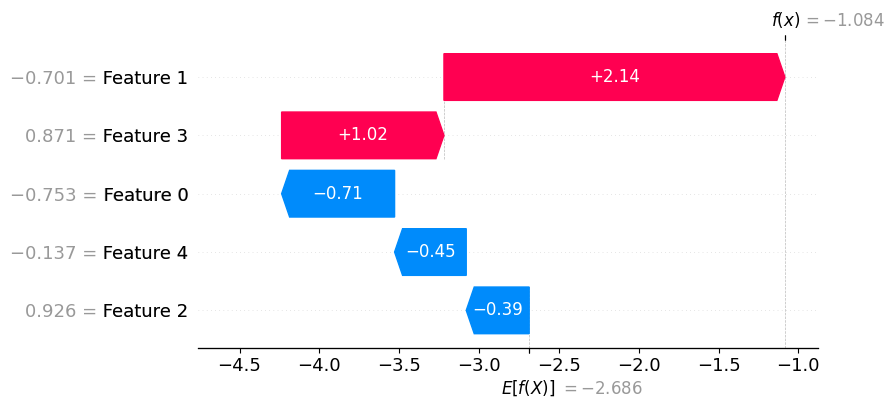

```python
import shap

explainer = shap.Explainer(cb, X)
shap_values = explainer(X[rows,:])
print("Shapley values for chosen samples:\n", shap_values.values)
print("Base values for chosen samples:\n", shap_values.base_values)
shap.initjs()
shap.plots.waterfall(shap_values[0])
```